# Series02-Rstudio-RENDU

2025-10-01

## 2.1 Make clear what is a statistical test, and when to use it.

Below are some questions to guide your analysis. You can answer them in your notebook, with a short sentence for each question.

- What is a median? A mean?

A median is the value right in the middle between the maximum and the minimum of the dataset. A mean is the average of all the values of the dataset.

- What is a variance? A standard deviation?

The variance is the measure of data spread, the average squared deviation from the mean. The standard deviation is the square root of the variance.

- What is a normal distribution?

A normal distribution is when the values are symetrical around the mean value. Graphicly, it has the shape of a bell.

- What is a statistical test?

A statistical test is a test that allows to decide of data support or reject the hypothesis H0 that was chosen before the test.

- When to use a statistical test?

When we need to determine of a result is statistically significant or if it’s due to chance or hazard.

- What is a parametric test? A non-parametric test?

A parametric test is a test where we assume a specific distribution. On the other end, a non-parametric test is where there are no distribution assumptions.

- What are the assumptions of parametric tests?

Normality, homogeneity of variances, independence of observations.

- What are the assumptions of non-parametric tests?

Often require independent samples and ordinal/continuous data.

- What is a p-value?

The p-value is the probability of obtaining data as extreme as observed, under the null hypothesis. It allows to know if there’s a correlation between two datasets.

- What is the risk of error when using a statistical test?

- What is the difference between a paired and an unpaired test?

A paired test compare measurements on the the same subjects before and after treatments while an unpaired test compare measurements between different groups.

# 2.2 Effect of Treatment Over Time

## 2.2.1 The Data

```r
# Load data
data_prepost <- read.csv("Datas/PrePost.csv")
print(data_prepost)
```

```
##    perf   time
## 1   125 Before
## 2   130 Before
## 3   132 Before
## 4   135 Before
## 5   136 Before
## 6   138 Before
## 7   140 Before
## 8   145 Before
## 9   127  After
## 10  132  After
## 11  133  After
## 12  136  After
## 13  139  After
## 14  141  After
## 15  145  After
## 16  148  After
```

Tableau des variables mesurées

| Variable | Description | Unit | Possible values | Expected change |
| --- | --- | --- | --- | --- |
| perf | Performance index | N/A | 125–148 | Increase |
| time | Measurement time | categorical | Before, After | N/A |

## 2.2.2 The analysis

- Does the treatment have an effect?

Yes, the treatment appears to have an effect: performance after rehabilitation is higher compared to before.

- What comparison are you going to make?

We compare the same individuals’ performance before vs. after rehabilitation (paired data).

- Which test will you use? Parametric or non-parametric?

The sataset is normally distributed so I will use a paired t-test (parametric).

- Which graph illustrates the effect of the treatment?

A boxplot (Before vs. After) or a line plot connecting paired observations best illustrates the effect.

```r
# Load PrePost data
data_prepost <- read.csv("Datas/PrePost.csv")


# Create ID variable for pairing
data_prepost$ID <- rep(1:(nrow(data_prepost)/2), times = 2)


# Ensure Before → After order
data_prepost$time <- factor(data_prepost$time, levels = c("Before", "After"), ordered = TRUE)


# Separate vectors for paired test
before <- data_prepost$perf[data_prepost$time == "Before"]
after <- data_prepost$perf[data_prepost$time == "After"]


# Paired t-test
paired_test <- t.test(before, after, paired = TRUE)
paired_test
```

```
##
##  Paired t-test
##
## data:  before and after
## t = -5.4006, df = 7, p-value = 0.001008
## alternative hypothesis: true mean difference is not equal to 0
## 95 percent confidence interval:
##  -3.594608 -1.405392
## sample estimates:
## mean difference
##            -2.5
```

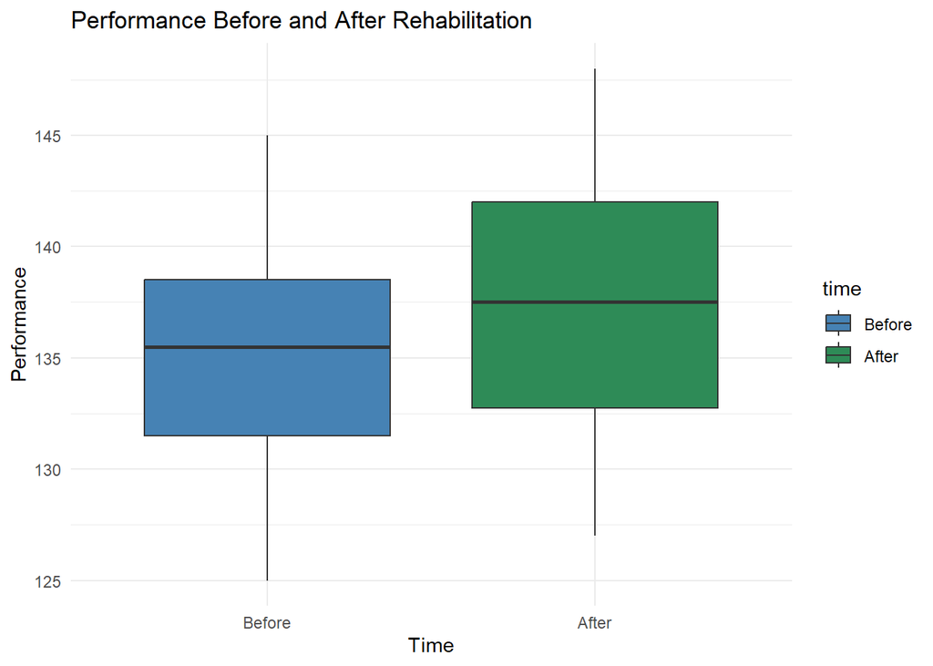

```r
# Boxplot with forced order

ggplot(data_prepost, aes(x = time, y = perf, fill = time)) +
geom_boxplot() +
scale_fill_manual(values = c("Before" = "steelblue", "After" = "seagreen")) +
labs(title = "Performance Before and After Rehabilitation",
x = "Time",
y = "Performance") +
scale_x_discrete(limits = c("Before", "After")) +
theme_minimal()
```

- What sentence will you write in your thesis to explain your result?

The rehabilitation training significantly improved participants’ performance, as shown by a paired t-test (p < 0.05).

# 2.3 Testing Some Stereotypes

## 2.3.1 The Data

```r
data_snore <- read.table("Datas/snore.txt", header = TRUE)
head(data_snore)
```

```
##   age weight height alcool sex snore tabac
## 1  47     71    158      0   H     N     O
## 2  56     58    164      7   H     O     N
## 3  46    116    208      3   H     N     O
## 4  70     96    186      3   H     N     O
## 5  51     91    195      2   H     O     O
## 6  46     98    188      0   F     N     N
```

## 2.3.2 The Analysis

### Are snorers fatter?

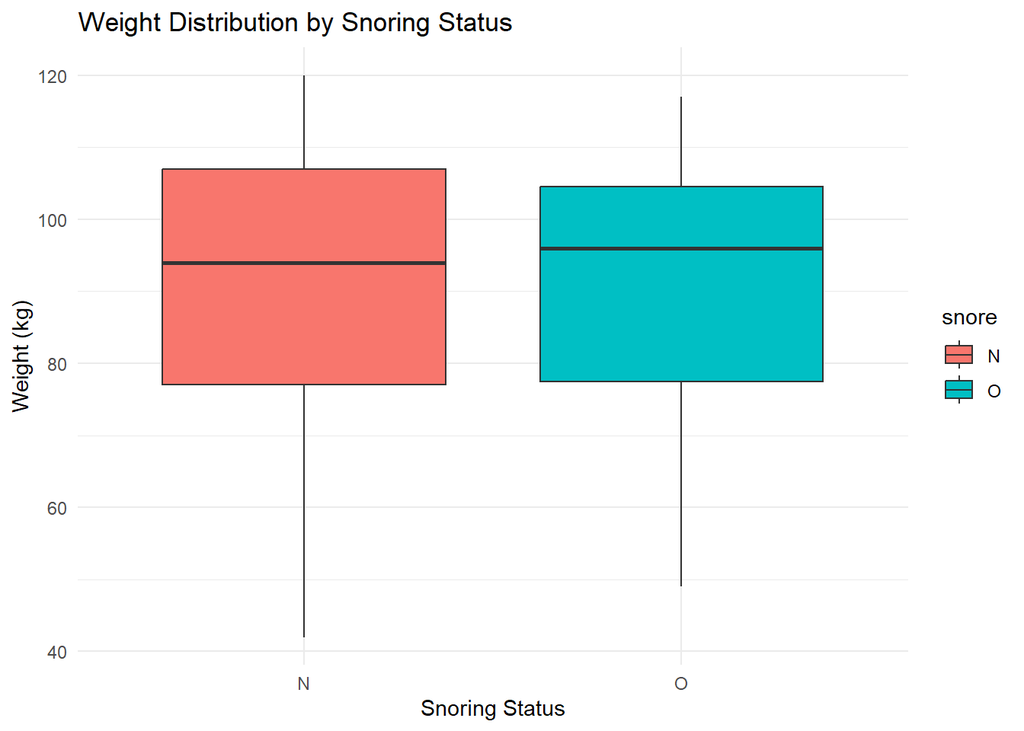

```r
# Box plot of weight by snoring status
ggplot(data_snore, aes(x = snore, y = weight, fill = snore)) +
  geom_boxplot() +
  labs(title = "Weight Distribution by Snoring Status",
       x = "Snoring Status",
       y = "Weight (kg)") +
  theme_minimal()
```

```r
# Summary statistics
data_snore %>%
  group_by(snore) %>%
  summarise(mean_weight = mean(weight, na.rm = TRUE),
            median_weight = median(weight, na.rm = TRUE),
            sd_weight = sd(weight, na.rm = TRUE))
```

```
## # A tibble: 2 × 4
##   snore mean_weight median_weight sd_weight
##   <chr>       <dbl>         <int>     <dbl>
## 1 N            90.5            94      19.0
## 2 O            90.3            96      18.4
```

The boxplots and the summary statistics are showing us that the weight distribution by the snoring status seems relatively equivalent so we could conclude that no, snorers aren’t fatter.

### Do snorers drink or smoke more?

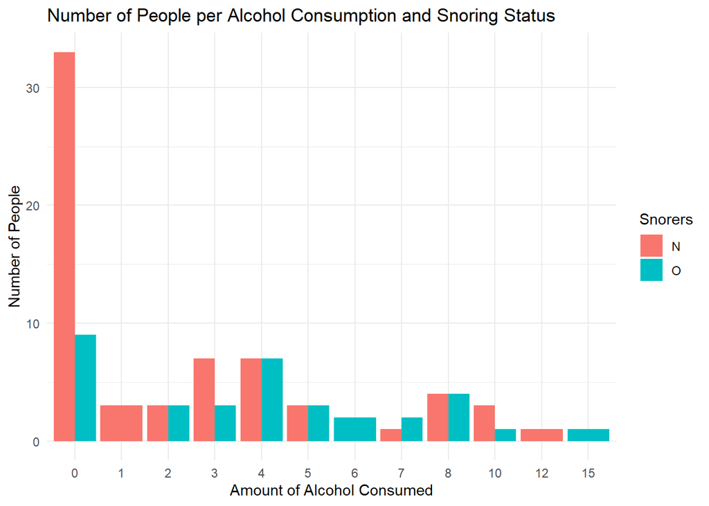

```r
# Bar plot of drinking status by snoring status
ggplot(data_snore, aes(x = factor(alcool), fill = factor(snore))) +
  geom_bar(position = "dodge") +
  labs(title = "Number of People per Alcohol Consumption and Snoring Status",
       x = "Amount of Alcohol Consumed",
       y = "Number of People",
       fill = "Snorers") +
  theme_minimal()
```

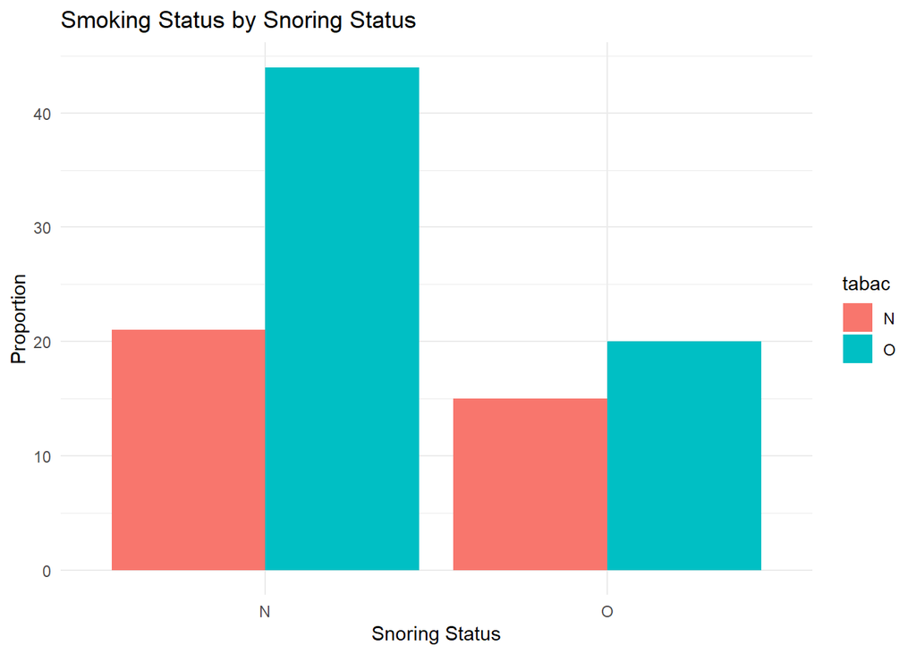

```r
# Bar plot of smoking status by snoring status
ggplot(data_snore, aes(x = snore, fill = tabac)) +
  geom_bar(position = "dodge") +
  labs(title = "Smoking Status by Snoring Status",
       x = "Snoring Status",
       y = "Proportion") +
  theme_minimal()
```

The first barplot can indicate that someone who doesn’t drink at all has a bigger chance to not snore but exept that, it seems that the snoring isn’t really related to the alcohol consumption.

### Are men fatter?

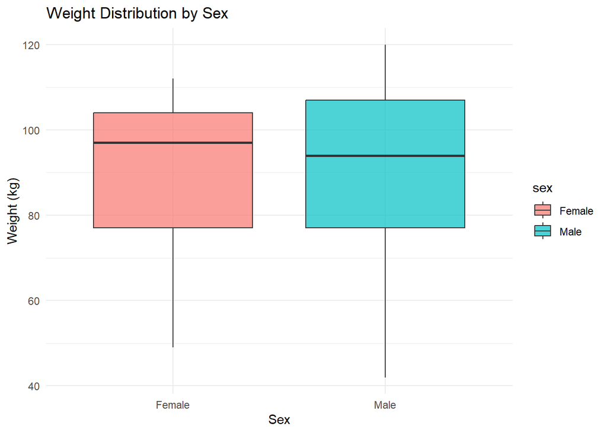

```r
data_snore$sex <- ifelse(data_snore$sex == "H", "Male", "Female")

ggplot(data_snore, aes(x = sex, y = weight, fill = sex)) +
  geom_boxplot(alpha = 0.7) +
  labs(title = "Weight Distribution by Sex",
       x = "Sex",
       y = "Weight (kg)") +
  theme_minimal()
```

```r
# Summary statistics
data_snore %>%
  group_by(sex) %>%
  summarise(
    count = n(),
    mean = mean(weight, na.rm = TRUE),
    sd = sd(weight, na.rm = TRUE),
    min = min(weight, na.rm = TRUE),
    Q1 = quantile(weight, 0.25, na.rm = TRUE),
    median = median(weight, na.rm = TRUE),
    Q3 = quantile(weight, 0.75, na.rm = TRUE),
    max = max(weight, na.rm = TRUE)
  )
```

```
## # A tibble: 2 × 9
##   sex    count  mean    sd   min    Q1 median    Q3   max
##   <chr>  <int> <dbl> <dbl> <int> <dbl>  <int> <dbl> <int>
## 1 Female    25  89.3  18.1    49    77     97   104   112
## 2 Male      75  90.8  19.1    42    77     94   107   120
```

### Do women smoke less?

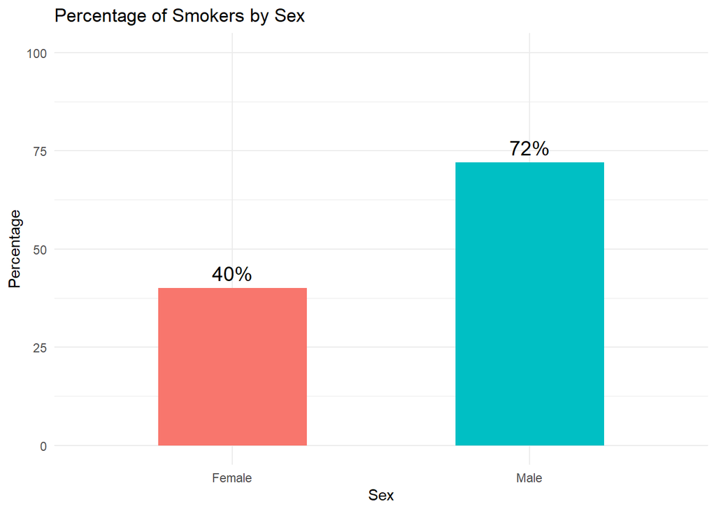

```r
# Calculate percentage of smokers by sex
smoking_percent <- data_snore %>%
  group_by(sex) %>%
  summarise(percent_smoker = mean(tabac == "O") * 100, .groups = "drop") %>%
  complete(sex, fill = list(percent_smoker = 0))

# Side-by-side bar plot
ggplot(smoking_percent, aes(x = sex, y = percent_smoker, fill = sex)) +
  geom_col(width = 0.5) +
  geom_text(aes(label = paste0(round(percent_smoker, 1), "%")),
            vjust = -0.5, size = 5) +
  coord_cartesian(ylim = c(0, 100)) +
  labs(title = "Percentage of Smokers by Sex",
       x = "Sex",
       y = "Percentage") +
  theme_minimal() +
  theme(legend.position = "none")
```

In this dataset, we have 40% of women smoking while 72% of men are smoking. So, following this dataset, we could say that yes, women smoke less than men.

### Correlations between variables

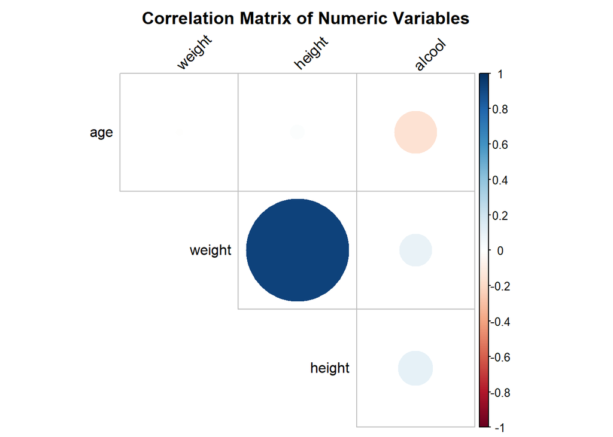

```r
numeric_vars <- data_snore %>% select(where(is.numeric))

cor_matrix <- cor(numeric_vars, use = "complete.obs")

corrplot(
  cor_matrix,
  method = "circle",
  type = "upper",
  diag = FALSE,
  tl.col = "black",
  tl.srt = 45,
  title = "Correlation Matrix of Numeric Variables",
  mar = c(0,0,2,0)
)
```